# Differential Gene Expression Analysis

Pan-cancer | Necroptosis, Ferroptosis & Pyroptosis

Kim Williame Lee[^1]

Mark Edward M. Gonzales[^2]

Dr. Anish M.S. Shrestha[^3]

## I. Preliminaries

### Loading libraries

```r
library("tidyverse")
library("tibble")
library("msigdbr")
library("ggplot2")
library("TCGAbiolinks")
library("RNAseqQC")
library("DESeq2")
library("ensembldb")
library("purrr")
library("magrittr")
library("vsn")
library("matrixStats")
library("dplyr")
library("grex")
```

## II. Downloading the TCGA gene expression data

Create a function for downloading TCGA gene expression data.

For more detailed documentation, refer to `2. Differential Gene Expression Analysis - TCGA.Rmd`.

```r
query_and_filter_samples <- function(project) {
  query_tumor <- GDCquery(
    project = project,
    data.category = "Transcriptome Profiling",
    data.type = "Gene Expression Quantification",
    experimental.strategy = "RNA-Seq",
    workflow.type = "STAR - Counts",
    access = "open",
    sample.type = "Primary Tumor"
  )
  tumor <- getResults(query_tumor)

  query_normal <- GDCquery(
    project = project,
    data.category = "Transcriptome Profiling",
    data.type = "Gene Expression Quantification",
    experimental.strategy = "RNA-Seq",
    workflow.type = "STAR - Counts",
    access = "open",
    sample.type = "Solid Tissue Normal"
  )
  normal <- getResults(query_normal)

  submitter_ids <- inner_join(tumor, normal, by = "cases.submitter_id") %>%
    dplyr::select(cases.submitter_id)
  tumor <- tumor %>%
    dplyr::filter(cases.submitter_id %in% submitter_ids$cases.submitter_id)
  normal <- normal %>%
    dplyr::filter(cases.submitter_id %in% submitter_ids$cases.submitter_id)

  samples <- rbind(tumor, normal)
  unique(samples$sample_type)

  query_project <- GDCquery(
    project = project,
    data.category = "Transcriptome Profiling",
    data.type = "Gene Expression Quantification",
    experimental.strategy = "RNA-Seq",
    workflow.type = "STAR - Counts",
    access = "open",
    sample.type = c("Solid Tissue Normal", "Primary Tumor"),
    barcode = as.list(samples$sample.submitter_id)
  )

  # If this is your first time running this notebook (i.e., you have not yet downloaded the results of the query in the previous block),
  # uncomment the line below

  # GDCdownload(query_project)

  return (list(samples = samples, query_project = query_project))
}
```

Download the TCGA gene expression data for different cancer types.

Refer to this link for the list of TCGA cancer type abbreviations: https://gdc.cancer.gov/resources-tcga-users/tcga-code-tables/tcga-study-abbreviations

```r
projects <- c("TCGA-LUSC", "TCGA-COAD", "TCGA-KICH", "TCGA-KIRC", "TCGA-PRAD",
              "TCGA-BRCA", "TCGA-HNSC", "TCGA-KIRP", "TCGA-LIHC", "TCGA-STAD",
              "TCGA-THCA", "TCGA-BLCA", "TCGA-LUAD", "TCGA-ESCA")

samples <- list()
project_data <- list()

for (project in projects) {
  result <- query_and_filter_samples(project)

  samples[[project]] <- result$samples
  project_data[[project]] <- result$query_project
}
```

Running the code block above should generate and populate a directory named `GDCdata`.

## III. Data preprocessing

Construct the RNA-seq count matrix for each cancer type.

```r
tcga_data <- list()
tcga_matrix <- list()

for (project in projects) {
  tcga_data[[project]] <- GDCprepare(project_data[[project]], summarizedExperiment = TRUE)
}
```

```r
for (project in projects) {
  count_matrix <- assay(tcga_data[[project]], "unstranded")

  # Remove duplicate entries
  count_matrix_df <- data.frame(count_matrix)
  count_matrix_df <- count_matrix_df[!duplicated(count_matrix_df), ]
  count_matrix <- data.matrix(count_matrix_df)
  rownames(count_matrix) <- cleanid(rownames(count_matrix))
  count_matrix <- count_matrix[!(duplicated(rownames(count_matrix)) | duplicated(rownames(count_matrix), fromLast = TRUE)), ]

  tcga_matrix[[project]] <- count_matrix
}
```

Format the `samples` table so that it can be fed as input to DESeq2.

```r
for (project in projects) {
  rownames(samples[[project]]) <- samples[[project]]$cases
  samples[[project]] <- samples[[project]] %>%
    dplyr::select(case = "cases.submitter_id", type = "sample_type")
  samples[[project]]$type <- str_replace(samples[[project]]$type, "Solid Tissue Normal", "normal")
  samples[[project]]$type <- str_replace(samples[[project]]$type, "Primary Tumor", "tumor")
}
```

DESeq2 requires the row names of `samples` should be identical to the column names of `count_matrix`.

```r
for (project in projects) {
  colnames(tcga_matrix[[project]]) <- gsub(x = colnames(tcga_matrix[[project]]), pattern = "\\.", replacement = "-")
  tcga_matrix[[project]] <- tcga_matrix[[project]][, rownames(samples[[project]])]

  # Sanity check
  print(all(colnames(tcga_matrix[[project]]) == rownames(samples[[project]])))
}
```

## IV. Differential gene expression analysis

References:

- Official documentation: https://www.bioconductor.org/packages/release/bioc/vignettes/DESeq2/inst/doc/DESeq2.html
- Good balance of theory and hands-on: https://hbctraining.github.io/DGE_workshop/lessons/04_DGE_DESeq2_analysis.html
- Quality control: https://cran.r-project.org/web/packages/RNAseqQC/vignettes/introduction.html

Construct the `DESeqDataSet` object for each cancer type.

```r
dds_results <- list()

for (project in projects) {
  dds_results[[project]] <- DESeqDataSetFromMatrix(
    countData = tcga_matrix[[project]],
    colData = samples[[project]],
    design = ~type
  )
}
```

### Regulated Cell Death

Refer to `1. Exploratory Data Analysis - MSigDB Gene Sets + GTEx TPM.Rmd` for more detailed documentation on obtaining the gene sets.

#### Necroptosis

Fetch the necroptosis gene set.

```r
necroptosis.genes <- msigdbr(species = "human", category = "C5", subcategory = "GO:BP") %>%
  dplyr::filter(gs_name == "GOBP_NECROPTOTIC_SIGNALING_PATHWAY")
necroptosis.genes
```

| gs_cat | gs_subcat | gs_name | gene_symbol | entrez_gene | ensembl_gene | human_gene_symbol | human_entrez_gene | human_ensembl_gene | gs_id | gs_pmid | gs_geoid | gs_exact_source | gs_url | gs_description |
| --- | --- | --- | --- | --- | --- | --- | --- | --- | --- | --- | --- | --- | --- | --- |
| C5 | GO:BP | GOBP_NECROPTOTIC_SIGNALING_PATHWAY | FADD | 8772 | ENSG00000168040 | FADD | 8772 | ENSG00000168040 | M24779 |  |  | GO:0097527 | http://amigo.geneontology.org/amigo/term/GO:0097527 | A series of molecular signals which triggers the necroptotic death of a cell. The pathway starts with reception of a signal, is characterized by activation of receptor-interacting serine/threonine-pro… |
| C5 | GO:BP | GOBP_NECROPTOTIC_SIGNALING_PATHWAY | FAS | 355 | ENSG00000026103 | FAS | 355 | ENSG00000026103 | M24779 |  |  | GO:0097527 | http://amigo.geneontology.org/amigo/term/GO:0097527 | A series of molecular signals which triggers the necroptotic death of a cell. The pathway starts with reception of a signal, is characterized by activation of receptor-interacting serine/threonine-pro… |
| C5 | GO:BP | GOBP_NECROPTOTIC_SIGNALING_PATHWAY | FASLG | 356 | ENSG00000117560 | FASLG | 356 | ENSG00000117560 | M24779 |  |  | GO:0097527 | http://amigo.geneontology.org/amigo/term/GO:0097527 | A series of molecular signals which triggers the necroptotic death of a cell. The pathway starts with reception of a signal, is characterized by activation of receptor-interacting serine/threonine-pro… |
| C5 | GO:BP | GOBP_NECROPTOTIC_SIGNALING_PATHWAY | MLKL | 197259 | ENSG00000168404 | MLKL | 197259 | ENSG00000168404 | M24779 |  |  | GO:0097527 | http://amigo.geneontology.org/amigo/term/GO:0097527 | A series of molecular signals which triggers the necroptotic death of a cell. The pathway starts with reception of a signal, is characterized by activation of receptor-interacting serine/threonine-pro… |
| C5 | GO:BP | GOBP_NECROPTOTIC_SIGNALING_PATHWAY | RIPK1 | 8737 | ENSG00000137275 | RIPK1 | 8737 | ENSG00000137275 | M24779 |  |  | GO:0097527 | http://amigo.geneontology.org/amigo/term/GO:0097527 | A series of molecular signals which triggers the necroptotic death of a cell. The pathway starts with reception of a signal, is characterized by activation of receptor-interacting serine/threonine-pro… |
| C5 | GO:BP | GOBP_NECROPTOTIC_SIGNALING_PATHWAY | RIPK3 | 11035 | ENSG00000129465 | RIPK3 | 11035 | ENSG00000129465 | M24779 |  |  | GO:0097527 | http://amigo.geneontology.org/amigo/term/GO:0097527 | A series of molecular signals which triggers the necroptotic death of a cell. The pathway starts with reception of a signal, is characterized by activation of receptor-interacting serine/threonine-pro… |
| C5 | GO:BP | GOBP_NECROPTOTIC_SIGNALING_PATHWAY | RIPK3 | 11035 | ENSG00000285379 | RIPK3 | 11035 | ENSG00000285379 | M24779 |  |  | GO:0097527 | http://amigo.geneontology.org/amigo/term/GO:0097527 | A series of molecular signals which triggers the necroptotic death of a cell. The pathway starts with reception of a signal, is characterized by activation of receptor-interacting serine/threonine-pro… |
| C5 | GO:BP | GOBP_NECROPTOTIC_SIGNALING_PATHWAY | TLR3 | 7098 | ENSG00000164342 | TLR3 | 7098 | ENSG00000164342 | M24779 |  |  | GO:0097527 | http://amigo.geneontology.org/amigo/term/GO:0097527 | A series of molecular signals which triggers the necroptotic death of a cell. The pathway starts with reception of a signal, is characterized by activation of receptor-interacting serine/threonine-pro… |
| C5 | GO:BP | GOBP_NECROPTOTIC_SIGNALING_PATHWAY | TNF | 7124 | ENSG00000204490 | TNF | 7124 | ENSG00000204490 | M24779 |  |  | GO:0097527 | http://amigo.geneontology.org/amigo/term/GO:0097527 | A series of molecular signals which triggers the necroptotic death of a cell. The pathway starts with reception of a signal, is characterized by activation of receptor-interacting serine/threonine-pro… |
| C5 | GO:BP | GOBP_NECROPTOTIC_SIGNALING_PATHWAY | TNF | 7124 | ENSG00000206439 | TNF | 7124 | ENSG00000206439 | M24779 |  |  | GO:0097527 | http://amigo.geneontology.org/amigo/term/GO:0097527 | A series of molecular signals which triggers the necroptotic death of a cell. The pathway starts with reception of a signal, is characterized by activation of receptor-interacting serine/threonine-pro… |

[output cut: 6 more lines]

Filter the genes to include only those in the necroptosis gene set.

```r
tcga_necroptosis <- list()

for (project in projects) {
  rownames(necroptosis.genes) <- necroptosis.genes$ensembl_gene
  tcga_necroptosis[[project]] <- tcga_matrix[[project]][rownames(tcga_matrix[[project]]) %in% necroptosis.genes$ensembl_gene, ]
  tcga_necroptosis[[project]] <- tcga_necroptosis[[project]][, rownames(samples[[project]])]

  # Check if all samples in the counts dataframe are in the samples dataframe
  print(all(colnames(tcga_necroptosis[[project]]) == rownames((samples[[project]]))))
}
```

Perform differential gene expression analysis.

```r
dds_necroptosis <- list()
res_necroptosis <- list()

for (project in projects) {
  print(project)
  print("=============")

  dds <- DESeqDataSetFromMatrix(
    countData = tcga_necroptosis[[project]],
    colData = samples[[project]],
    design = ~type
  )
  dds <- filter_genes(dds, min_count = 10)
  dds$type <- relevel(dds$type, ref = "normal")
  dds_necroptosis[[project]] <- DESeq(dds)
  res_necroptosis[[project]] <- results(dds_necroptosis[[project]])
}
```

```
[1] "TCGA-LUSC"
[1] "============="
```

```
[1] "TCGA-COAD"
[1] "============="
```

```
[1] "TCGA-KICH"
[1] "============="
```

```
[1] "TCGA-KIRC"
[1] "============="
```

```
[1] "TCGA-PRAD"
[1] "============="
```

```
[1] "TCGA-BRCA"
[1] "============="
```

```
[1] "TCGA-HNSC"
[1] "============="
```

```
[1] "TCGA-KIRP"
[1] "============="
```

```
[1] "TCGA-LIHC"
[1] "============="
```

```
[1] "TCGA-STAD"
[1] "============="
```

```
[1] "TCGA-THCA"
[1] "============="
```

```
[1] "TCGA-BLCA"
[1] "============="
```

```
[1] "TCGA-LUAD"
[1] "============="
```

```
[1] "TCGA-ESCA"
[1] "============="
```

Prettify the display of results.

```r
deseq.bbl.data <- list()

for (project in projects) {
  deseq.results <- res_necroptosis[[project]]
  deseq.bbl.data[[project]] <- data.frame(
    row.names = rownames(deseq.results),
    baseMean = deseq.results$baseMean,
    log2FoldChange = deseq.results$log2FoldChange,
    lfcSE = deseq.results$lfcSE,
    stat = deseq.results$stat,
    pvalue = deseq.results$pvalue,
    padj = deseq.results$padj,
    cancer_type = project,
    gene_symbol = necroptosis.genes[rownames(deseq.results), "gene_symbol"]
  )
}

deseq.bbl.data.combined <- bind_rows(deseq.bbl.data)
deseq.bbl.data.combined <- dplyr::filter(deseq.bbl.data.combined, abs(log2FoldChange) >= 1.5 & padj < 0.05)
deseq.bbl.data.combined
```

|  | baseMean | log2FoldChange | lfcSE | stat | pvalue | padj | cancer_type | gene_symbol |
| --- | --- | --- | --- | --- | --- | --- | --- | --- |
| ENSG00000168040...1 | 213.21942 | 2.257697 | 0.1939151 | 11.642706 | 2.499584e-31 | 1.999667e-30 | TCGA-LUSC | FADD |
| ENSG00000117560...2 | 18.64931 | 1.952305 | 0.2743739 | 7.115491 | 1.115154e-12 | 8.921231e-12 | TCGA-KICH | FASLG |
| ENSG00000117560...3 | 65.73297 | 2.445533 | 0.1883506 | 12.983936 | 1.509206e-38 | 6.036823e-38 | TCGA-KIRC | FASLG |
| ENSG00000168040...4 | 246.85939 | 1.886482 | 0.2084418 | 9.050402 | 1.424433e-19 | 1.139546e-18 | TCGA-HNSC | FADD |
| ENSG00000232810 | 111.61006 | 2.130035 | 0.5378613 | 3.960194 | 7.488896e-05 | 5.991117e-04 | TCGA-ESCA | TNF |

Plot the results.

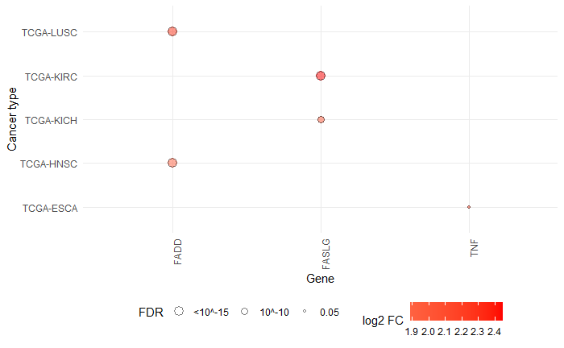

```r
sizes <- c("<10^-15" = 4, "10^-10" = 3, "10^-5" = 2, "0.05" = 1)

deseq.bbl.data.combined <- deseq.bbl.data.combined %>%
  mutate(fdr_category = cut(padj,
                            breaks = c(-Inf, 1e-15, 1e-10, 1e-5, 0.05),
                            labels = c("<10^-15", "10^-10", "10^-5", "0.05"),
                            right = FALSE))

top_genes <- deseq.bbl.data.combined %>%
  group_by(cancer_type) %>%
  mutate(rank = rank(-abs(log2FoldChange))) %>%
  dplyr::filter(rank <= 10) %>%
  ungroup()

ggplot(top_genes, aes(y=cancer_type, x=gene_symbol, size=fdr_category, fill=log2FoldChange)) +
    geom_point(alpha=0.5, shape=21, color="black") +
    scale_size_manual(values = sizes) +
    scale_fill_gradient2(low = "blue", mid = "white", high = "red", limits = c(min(deseq.bbl.data.combined$log2FoldChange),max(deseq.bbl.data.combined$log2FoldChange))) +
    theme_minimal() +
    theme(
      axis.text.x = element_text(size = 9, angle = 90, hjust = 1)
    ) +
    theme(legend.position="bottom") +
    theme(legend.position = "bottom")+
    labs(size = "FDR", fill = "log2 FC", y = "Cancer type", x = "Gene")
```

#### Ferroptosis

Fetch the ferroptosis gene set.

```r
ferroptosis.genes <- msigdbr(species = "human", category = "C2", subcategory = "CP:WIKIPATHWAYS") %>%
  dplyr::filter(gs_name == "WP_FERROPTOSIS")
ferroptosis.genes
```

| gs_cat | gs_subcat | gs_name | gene_symbol | entrez_gene | ensembl_gene | human_gene_symbol | human_entrez_gene | human_ensembl_gene | gs_id | gs_pmid | gs_geoid | gs_exact_source | gs_url | gs_description |
| --- | --- | --- | --- | --- | --- | --- | --- | --- | --- | --- | --- | --- | --- | --- |
| C2 | CP:WIKIPATHWAYS | WP_FERROPTOSIS | ACSL1 | 2180 | ENSG00000151726 | ACSL1 | 2180 | ENSG00000151726 | M39768 |  |  | WP4313 | http://www.wikipathways.org/instance/WP4313_r120500 | Ferroptosis |
| C2 | CP:WIKIPATHWAYS | WP_FERROPTOSIS | ACSL3 | 2181 | ENSG00000123983 | ACSL3 | 2181 | ENSG00000123983 | M39768 |  |  | WP4313 | http://www.wikipathways.org/instance/WP4313_r120500 | Ferroptosis |
| C2 | CP:WIKIPATHWAYS | WP_FERROPTOSIS | ACSL4 | 2182 | ENSG00000068366 | ACSL4 | 2182 | ENSG00000068366 | M39768 |  |  | WP4313 | http://www.wikipathways.org/instance/WP4313_r120500 | Ferroptosis |
| C2 | CP:WIKIPATHWAYS | WP_FERROPTOSIS | ACSL5 | 51703 | ENSG00000197142 | ACSL5 | 51703 | ENSG00000197142 | M39768 |  |  | WP4313 | http://www.wikipathways.org/instance/WP4313_r120500 | Ferroptosis |
| C2 | CP:WIKIPATHWAYS | WP_FERROPTOSIS | ACSL6 | 23305 | ENSG00000164398 | ACSL6 | 23305 | ENSG00000164398 | M39768 |  |  | WP4313 | http://www.wikipathways.org/instance/WP4313_r120500 | Ferroptosis |
| C2 | CP:WIKIPATHWAYS | WP_FERROPTOSIS | AIFM2 | 84883 | ENSG00000042286 | AIFM2 | 84883 | ENSG00000042286 | M39768 |  |  | WP4313 | http://www.wikipathways.org/instance/WP4313_r120500 | Ferroptosis |
| C2 | CP:WIKIPATHWAYS | WP_FERROPTOSIS | AKR1C1 | 1645 | ENSG00000187134 | AKR1C1 | 1645 | ENSG00000187134 | M39768 |  |  | WP4313 | http://www.wikipathways.org/instance/WP4313_r120500 | Ferroptosis |
| C2 | CP:WIKIPATHWAYS | WP_FERROPTOSIS | AKR1C2 | 1646 | ENSG00000151632 | AKR1C2 | 1646 | ENSG00000151632 | M39768 |  |  | WP4313 | http://www.wikipathways.org/instance/WP4313_r120500 | Ferroptosis |
| C2 | CP:WIKIPATHWAYS | WP_FERROPTOSIS | AKR1C3 | 8644 | ENSG00000196139 | AKR1C3 | 8644 | ENSG00000196139 | M39768 |  |  | WP4313 | http://www.wikipathways.org/instance/WP4313_r120500 | Ferroptosis |
| C2 | CP:WIKIPATHWAYS | WP_FERROPTOSIS | ALOX15 | 246 | ENSG00000161905 | ALOX15 | 246 | ENSG00000161905 | M39768 |  |  | WP4313 | http://www.wikipathways.org/instance/WP4313_r120500 | Ferroptosis |

[output cut: 56 more lines]

Filter the genes to include only those in the ferroptosis gene set.

```r
tcga_ferroptosis <- list()

for (project in projects) {
  rownames(ferroptosis.genes) <- ferroptosis.genes$ensembl_gene
  tcga_ferroptosis[[project]] <- tcga_matrix[[project]][rownames(tcga_matrix[[project]]) %in% ferroptosis.genes$ensembl_gene, ]
  tcga_ferroptosis[[project]] <- tcga_ferroptosis[[project]][, rownames(samples[[project]])]

  # Check if all samples in the counts dataframe are in the samples dataframe
  print(all(colnames(tcga_ferroptosis[[project]]) == rownames((samples[[project]]))))
}
```

Perform differential gene expression analysis.

```r
dds_ferroptosis <- list()
res_ferroptosis <- list()

for (project in projects) {
  print(project)
  print("=============")

  dds <- DESeqDataSetFromMatrix(
    countData = tcga_ferroptosis[[project]],
    colData = samples[[project]],
    design = ~type
  )
  dds <- filter_genes(dds, min_count = 10)
  dds$type <- relevel(dds$type, ref = "normal")
  dds_ferroptosis[[project]] <- DESeq(dds)
  res_ferroptosis[[project]] <- results(dds_ferroptosis[[project]])
}
```

```
[1] "TCGA-LUSC"
[1] "============="
```

```
[1] "TCGA-COAD"
[1] "============="
```

```
[1] "TCGA-KICH"
[1] "============="
```

```
[1] "TCGA-KIRC"
[1] "============="
```

```
[1] "TCGA-PRAD"
[1] "============="
```

```
[1] "TCGA-BRCA"
[1] "============="
```

```
[1] "TCGA-HNSC"
[1] "============="
```

```
[1] "TCGA-KIRP"
[1] "============="
```

```
[1] "TCGA-LIHC"
[1] "============="
```

```
[1] "TCGA-STAD"
[1] "============="
```

```
[1] "TCGA-THCA"
[1] "============="
```

```
[1] "TCGA-BLCA"
[1] "============="
```

```
[1] "TCGA-LUAD"
[1] "============="
```

```
[1] "TCGA-ESCA"
[1] "============="
```

Prettify the display of results.

```r
deseq.bbl.data <- list()

for (project in projects) {
  deseq.results <- res_ferroptosis[[project]]
  deseq.bbl.data[[project]] <- data.frame(
    row.names = rownames(deseq.results),
    baseMean = deseq.results$baseMean,
    log2FoldChange = deseq.results$log2FoldChange,
    lfcSE = deseq.results$lfcSE,
    stat = deseq.results$stat,
    pvalue = deseq.results$pvalue,
    padj = deseq.results$padj,
    cancer_type = project,
    gene_symbol = ferroptosis.genes[rownames(deseq.results), "gene_symbol"]
  )
}

deseq.bbl.data.combined <- bind_rows(deseq.bbl.data)
deseq.bbl.data.combined <- dplyr::filter(deseq.bbl.data.combined, abs(log2FoldChange) >= 1.5 & padj < 0.05)
deseq.bbl.data.combined
```

|  | baseMean | log2FoldChange | lfcSE | stat | pvalue | padj | cancer_type | gene_symbol |
| --- | --- | --- | --- | --- | --- | --- | --- | --- |
| ENSG00000001084...1 | 6757.923393 | 3.028025 | 0.2138281 | 14.161021 | 1.596564e-45 | 2.514589e-44 | TCGA-LUSC | GCLC |
| ENSG00000023909...2 | 4119.489155 | 1.937989 | 0.2073199 | 9.347816 | 8.947625e-21 | 3.523128e-20 | TCGA-LUSC | GCLM |
| ENSG00000086991...3 | 328.449608 | 1.537311 | 0.2170045 | 7.084236 | 1.398131e-12 | 3.670094e-12 | TCGA-LUSC | NOX4 |
| ENSG00000106211...4 | 39522.979788 | 1.879999 | 0.1321895 | 14.222007 | 6.690658e-46 | 1.405038e-44 | TCGA-LUSC | HSPB1 |
| ENSG00000138449 | 13721.008036 | -1.733020 | 0.1501847 | -11.539253 | 8.364867e-31 | 6.587333e-30 | TCGA-LUSC | SLC40A1 |
| ENSG00000138821...6 | 21577.805350 | -3.429402 | 0.1864712 | -18.391053 | 1.549405e-75 | 9.761248e-74 | TCGA-LUSC | SLC39A8 |
| ENSG00000151012...7 | 2054.461463 | 3.673366 | 0.2823692 | 13.009087 | 1.086322e-38 | 1.140638e-37 | TCGA-LUSC | SLC7A11 |
| ENSG00000151632...8 | 12013.448996 | 4.894631 | 0.3352977 | 14.597864 | 2.897841e-48 | 9.128198e-47 | TCGA-LUSC | AKR1C2 |
| ENSG00000165168...9 | 11415.086773 | -1.908225 | 0.2019105 | -9.450847 | 3.361009e-21 | 1.411624e-20 | TCGA-LUSC | CYBB |
| ENSG00000187134...10 | 14829.289071 | 3.930250 | 0.3473992 | 11.313355 | 1.126964e-29 | 6.454429e-29 | TCGA-LUSC | AKR1C1 |

[output cut: 112 more lines]

Plot the results.

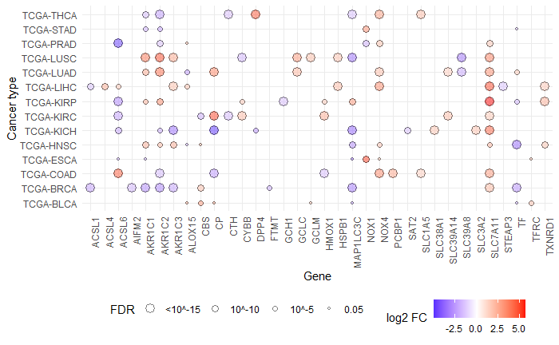

```r
deseq.bbl.data.combined <- deseq.bbl.data.combined %>%
  mutate(fdr_category = cut(padj,
                            breaks = c(-Inf, 1e-15, 1e-10, 1e-5, 0.05),
                            labels = c("<10^-15", "10^-10", "10^-5", "0.05"),
                            right = FALSE))

top_genes <- deseq.bbl.data.combined %>%
  group_by(cancer_type) %>%
  mutate(rank = rank(-abs(log2FoldChange))) %>%
  dplyr::filter(rank <= 10) %>%
  ungroup()

ggplot(top_genes, aes(y=cancer_type, x=gene_symbol, size=fdr_category, fill=log2FoldChange)) +
    geom_point(alpha=0.5, shape=21, color="black") +
    scale_size_manual(values = sizes) +
    scale_fill_gradient2(low = "blue", mid = "white", high = "red", limits = c(min(deseq.bbl.data.combined$log2FoldChange),max(deseq.bbl.data.combined$log2FoldChange))) +
    theme_minimal() +
    theme(
      axis.text.x = element_text(size = 9, angle = 90, hjust = 1)
    ) +
    theme(legend.position="bottom") +
    theme(legend.position = "bottom")+
    labs(size = "FDR", fill = "log2 FC", y = "Cancer type", x = "Gene")
```

#### Pyroptosis

Fetch the pyroptosis gene set.

```r
pyroptosis.genes <- msigdbr(species = "human", category = "C2", subcategory = "CP:REACTOME") %>%
  dplyr::filter(gs_name == "REACTOME_PYROPTOSIS")
pyroptosis.genes
```

| gs_cat | gs_subcat | gs_name | gene_symbol | entrez_gene | ensembl_gene | human_gene_symbol | human_entrez_gene | human_ensembl_gene | gs_id | gs_pmid | gs_geoid | gs_exact_source | gs_url | gs_description |
| --- | --- | --- | --- | --- | --- | --- | --- | --- | --- | --- | --- | --- | --- | --- |
| C2 | CP:REACTOME | REACTOME_PYROPTOSIS | BAK1 | 578 | ENSG00000030110 | BAK1 | 578 | ENSG00000030110 | M41805 |  |  | R-HSA-5620971 | https://www.reactome.org/content/detail/R-HSA-5620971\|https://reactome.org/PathwayBrowser/#/R-HSA-5620971 | Pyroptosis |
| C2 | CP:REACTOME | REACTOME_PYROPTOSIS | BAX | 581 | ENSG00000087088 | BAX | 581 | ENSG00000087088 | M41805 |  |  | R-HSA-5620971 | https://www.reactome.org/content/detail/R-HSA-5620971\|https://reactome.org/PathwayBrowser/#/R-HSA-5620971 | Pyroptosis |
| C2 | CP:REACTOME | REACTOME_PYROPTOSIS | CASP1 | 834 | ENSG00000137752 | CASP1 | 834 | ENSG00000137752 | M41805 |  |  | R-HSA-5620971 | https://www.reactome.org/content/detail/R-HSA-5620971\|https://reactome.org/PathwayBrowser/#/R-HSA-5620971 | Pyroptosis |
| C2 | CP:REACTOME | REACTOME_PYROPTOSIS | CASP3 | 836 | ENSG00000164305 | CASP3 | 836 | ENSG00000164305 | M41805 |  |  | R-HSA-5620971 | https://www.reactome.org/content/detail/R-HSA-5620971\|https://reactome.org/PathwayBrowser/#/R-HSA-5620971 | Pyroptosis |
| C2 | CP:REACTOME | REACTOME_PYROPTOSIS | CASP4 | 837 | ENSG00000196954 | CASP4 | 837 | ENSG00000196954 | M41805 |  |  | R-HSA-5620971 | https://www.reactome.org/content/detail/R-HSA-5620971\|https://reactome.org/PathwayBrowser/#/R-HSA-5620971 | Pyroptosis |
| C2 | CP:REACTOME | REACTOME_PYROPTOSIS | CASP5 | 838 | ENSG00000137757 | CASP5 | 838 | ENSG00000137757 | M41805 |  |  | R-HSA-5620971 | https://www.reactome.org/content/detail/R-HSA-5620971\|https://reactome.org/PathwayBrowser/#/R-HSA-5620971 | Pyroptosis |
| C2 | CP:REACTOME | REACTOME_PYROPTOSIS | CHMP2A | 27243 | ENSG00000130724 | CHMP2A | 27243 | ENSG00000130724 | M41805 |  |  | R-HSA-5620971 | https://www.reactome.org/content/detail/R-HSA-5620971\|https://reactome.org/PathwayBrowser/#/R-HSA-5620971 | Pyroptosis |
| C2 | CP:REACTOME | REACTOME_PYROPTOSIS | CHMP2B | 25978 | ENSG00000083937 | CHMP2B | 25978 | ENSG00000083937 | M41805 |  |  | R-HSA-5620971 | https://www.reactome.org/content/detail/R-HSA-5620971\|https://reactome.org/PathwayBrowser/#/R-HSA-5620971 | Pyroptosis |
| C2 | CP:REACTOME | REACTOME_PYROPTOSIS | CHMP3 | 51652 | ENSG00000115561 | CHMP3 | 51652 | ENSG00000115561 | M41805 |  |  | R-HSA-5620971 | https://www.reactome.org/content/detail/R-HSA-5620971\|https://reactome.org/PathwayBrowser/#/R-HSA-5620971 | Pyroptosis |
| C2 | CP:REACTOME | REACTOME_PYROPTOSIS | CHMP4A | 29082 | ENSG00000254505 | CHMP4A | 29082 | ENSG00000254505 | M41805 |  |  | R-HSA-5620971 | https://www.reactome.org/content/detail/R-HSA-5620971\|https://reactome.org/PathwayBrowser/#/R-HSA-5620971 | Pyroptosis |

[output cut: 20 more lines]

Filter the genes to include only those in the pyroptosis gene set.

```r
tcga_pyroptosis <- list()

for (project in projects) {
  rownames(pyroptosis.genes) <- pyroptosis.genes$ensembl_gene
  tcga_pyroptosis[[project]] <- tcga_matrix[[project]][rownames(tcga_matrix[[project]]) %in% pyroptosis.genes$ensembl_gene, ]
  tcga_pyroptosis[[project]] <- tcga_pyroptosis[[project]][, rownames(samples[[project]])]

  # Check if all samples in the counts dataframe are in the samples dataframe
  print(all(colnames(tcga_pyroptosis[[project]]) == rownames((samples[[project]]))))
}
```

Perform differential gene expression analysis.

```r
dds_pyroptosis <- list()
res_pyroptosis <- list()

for (project in projects) {
  print(project)
  print("=============")

  dds <- DESeqDataSetFromMatrix(
    countData = tcga_pyroptosis[[project]],
    colData = samples[[project]],
    design = ~type
  )
  dds <- filter_genes(dds, min_count = 10)
  dds$type <- relevel(dds$type, ref = "normal")
  dds_pyroptosis[[project]] <- DESeq(dds)
  res_pyroptosis[[project]] <- results(dds_pyroptosis[[project]])
}
```

```
[1] "TCGA-LUSC"
[1] "============="
```

```
[1] "TCGA-COAD"
[1] "============="
```

```
[1] "TCGA-KICH"
[1] "============="
```

```
[1] "TCGA-KIRC"
[1] "============="
```

```
[1] "TCGA-PRAD"
[1] "============="
```

```
[1] "TCGA-BRCA"
[1] "============="
```

```
[1] "TCGA-HNSC"
[1] "============="
```

```
[1] "TCGA-KIRP"
[1] "============="
```

```
[1] "TCGA-LIHC"
[1] "============="
```

```
[1] "TCGA-STAD"
[1] "============="
```

```
[1] "TCGA-THCA"
[1] "============="
```

```
[1] "TCGA-BLCA"
[1] "============="
```

```
[1] "TCGA-LUAD"
[1] "============="
```

```
[1] "TCGA-ESCA"
[1] "============="
```

Prettify the display of results.

```r
deseq.bbl.data <- list()

for (project in projects) {
  deseq.results <- res_pyroptosis[[project]]
  deseq.bbl.data[[project]] <- data.frame(
    row.names = rownames(deseq.results),
    baseMean = deseq.results$baseMean,
    log2FoldChange = deseq.results$log2FoldChange,
    lfcSE = deseq.results$lfcSE,
    stat = deseq.results$stat,
    pvalue = deseq.results$pvalue,
    padj = deseq.results$padj,
    cancer_type = project,
    gene_symbol = pyroptosis.genes[rownames(deseq.results), "gene_symbol"]
  )
}

deseq.bbl.data.combined <- bind_rows(deseq.bbl.data)
deseq.bbl.data.combined <- dplyr::filter(deseq.bbl.data.combined, abs(log2FoldChange) >= 1.5 & padj < 0.05)
deseq.bbl.data.combined
```

|  | baseMean | log2FoldChange | lfcSE | stat | pvalue | padj | cancer_type | gene_symbol |
| --- | --- | --- | --- | --- | --- | --- | --- | --- |
| ENSG00000073282...1 | 18109.361606 | 5.848317 | 0.2927416 | 19.977743 | 8.602579e-89 | 2.322696e-87 | TCGA-LUSC | TP63 |
| ENSG00000105928...2 | 1311.805751 | 1.574847 | 0.1906150 | 8.261925 | 1.433413e-16 | 5.528880e-16 | TCGA-LUSC | GSDME |
| ENSG00000137757...3 | 61.505944 | -1.621969 | 0.1685640 | -9.622270 | 6.439437e-22 | 3.477296e-21 | TCGA-LUSC | CASP5 |
| ENSG00000197561...4 | 23.263096 | -2.925494 | 0.2438930 | -11.994987 | 3.774749e-33 | 5.095911e-32 | TCGA-LUSC | ELANE |
| ENSG00000100453...5 | 367.990135 | 2.574438 | 0.2675027 | 9.623972 | 6.333714e-22 | 5.700343e-21 | TCGA-COAD | GZMB |
| ENSG00000115008...6 | 54.207664 | 2.962910 | 0.3028291 | 9.784099 | 1.317631e-22 | 1.778802e-21 | TCGA-COAD | IL1A |
| ENSG00000125538...7 | 637.828903 | 1.600628 | 0.2784449 | 5.748455 | 9.006257e-09 | 3.039612e-08 | TCGA-COAD | IL1B |
| ENSG00000137757...8 | 489.985448 | -2.091671 | 0.2304778 | -9.075371 | 1.132909e-19 | 6.117710e-19 | TCGA-COAD | CASP5 |
| ENSG00000197561...9 | 15.824550 | -2.709973 | 0.2614976 | -10.363284 | 3.642373e-25 | 9.834407e-24 | TCGA-COAD | ELANE |
| ENSG00000105928...10 | 865.262735 | -2.406026 | 0.2100263 | -11.455835 | 2.198352e-30 | 2.967776e-29 | TCGA-KICH | GSDME |

[output cut: 25 more lines]

Plot the results.

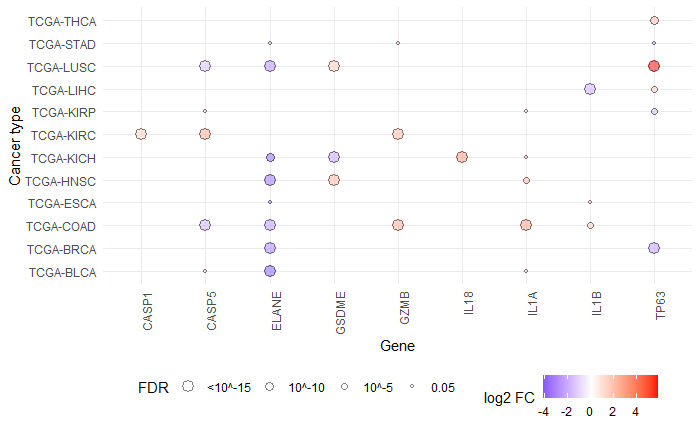

```r
deseq.bbl.data.combined <- deseq.bbl.data.combined %>%
  mutate(fdr_category = cut(padj,
                            breaks = c(-Inf, 1e-15, 1e-10, 1e-5, 0.05),
                            labels = c("<10^-15", "10^-10", "10^-5", "0.05"),
                            right = FALSE))

top_genes <- deseq.bbl.data.combined %>%
  group_by(cancer_type) %>%
  mutate(rank = rank(-abs(log2FoldChange))) %>%
  dplyr::filter(rank <= 10) %>%
  ungroup()

ggplot(top_genes, aes(y=cancer_type, x=gene_symbol, size=fdr_category, fill=log2FoldChange)) +
    geom_point(alpha=0.5, shape=21, color="black") +
    scale_size_manual(values = sizes) +
    scale_fill_gradient2(low = "blue", mid = "white", high = "red", limits = c(min(deseq.bbl.data.combined$log2FoldChange),max(deseq.bbl.data.combined$log2FoldChange))) +
    theme_minimal() +
    theme(
      axis.text.x = element_text(size = 9, angle = 90, hjust = 1)
    ) +
    theme(legend.position="bottom") +
    theme(legend.position = "bottom")+
    labs(size = "FDR", fill = "log2 FC", y = "Cancer type", x = "Gene")
```

[^1]: De La Salle University, Manila, Philippines, kim_leejra@dlsu.edu.ph
[^2]: De La Salle University, Manila, Philippines, gonzales.markedward@gmail.com
[^3]: De La Salle University, Manila, Philippines, anish.shrestha@dlsu.edu.ph